# Analyzing the Hong Kong protests using ACLED data

Juliette Rihl

4/24/2022

# Introduction

2019 and 2020 were tumultuous years for Hong Kong. The city, which is a special administrative region of China, saw [massive protests](https://www.reuters.com/article/us-hongkong-protests-timeline/timeline-key-dates-in-hong-kongs-anti-government-protests-idUSKBN23608O) following the proposal of a bill that would have allowed for extraditions to mainland China.

This markdown shows how the number of protests and riots in Hong Kong following the extradition bill has changed since the protests started on March 31, 2019. It also shows how the trend of violence against civilians — sometimes, but not always, committed by state actors— has changed since that date.

### About the data

The data is from the [Armed Conflict Location & Event Data Project (ACLED)](https://acleddata.com/#/dashboard). ACLED has several regional datasets — I used the East Asia Pacific one, which can be downloaded from ACLED’s website.

Here are the [data dictionary](https://acleddata.com/acleddatanew//wp-content/uploads/2021/11/ACLED_Codebook_v1_January-2021.pdf) and [event definitions](https://acleddata.com/download/35134/), as provided by ACLED.

# Extradition Protests and Riots

There have been 464 protests and riots in Hong Kong over the extradition bill since March 31, 2019. Take a look:

| Event Type | Date | Description |
| --- | --- | --- |
| Protests | 09 December 2021 | On 9 December 2021, members of a pro-Beijing citizen group, 'Apple Daily Fake News Monitoring Group,' gathered outside the Wanchai Law Courts Building in Wanchai district (Hong Kong) (coded as Hong Ko… |
| Protests | 01 November 2021 | On 1 November 2021, members of the pro-establishment group Politihk Social Strategic gathered outside the District Court in Wanchai district (Hong Kong) (coded as Hong Kong - Wan Chai) ahead of a tria… |
| Protests | 31 October 2021 | On 31 October 2021, 4 pro-democracy protesters displayed a banner in Mong Kok district, Hong Kong (coded as Hong Kong - Yau Tsim Mong), demanding genuine universal suffrage. Police arrested all of the… |
| Protests | 25 October 2021 | On 25 October 2021, New Millenarian members protested at Consulate General of the United States, Hong Kong and Macau at Chater Garden in Central (Hong Kong) (coded as Hong Kong - Central and Western) … |
| Protests | 16 October 2021 | On 16 October 2021, 3 members of the League of Social Democrats rallied outside the District Court in Wan Chai, Hong Kong (coded as Hong Kong - Wan Chai), ahead of a court session. They supported seve… |
| Protests | 01 October 2021 | On 1 October 2021, on Chinese National Day, 4 members of the LSD marched towards the Hong Kong Convention and Exhibition Centre in Wan Chai District, Hong Kong (coded as Hong Kong - Wan Chai), where t… |
| Protests | 17 September 2021 | On 17 September 2021, members of a pro-Beijing citizen group, Apple Daily Fake News Monitoring Group, protested at the Police Headquarters in Wanchai district (Hong Kong) (coded as Hong Kong - Wan Cha… |
| Protests | 15 September 2021 | On 15 September 2021, four members of the League of Social Democrats and an elderly activist rallied outside the District Court in Wan Chai, Hong Kong (coded as Hong Kong - Wan Chai), ahead of a court… |
| Protests | 13 September 2021 | On 13 September 2021, members of Defend Hong Kong Campaign gathered at the Police Headquarters in Wan Chai (Hong Kong) (coded as Hong Kong - Wan Chai) to protest against a Taiwan-made board game calle… |
| Protests | 01 September 2021 | On 1 September 2021, four representatives of League of Social Democrats activists gathered at the District Court in Wan Chai, Hong Kong (coded as Hong Kong - Wan Chai) to protest the sentence of seven… |

[output cut: 454 more lines]

## Declination in protests and riots

In 2019 and 2020, the city saw roughly 200 protests and riots related to the extradition bill. But since then, the unrest has settled, with far fewer protests in 2021 and none yet in 2022.

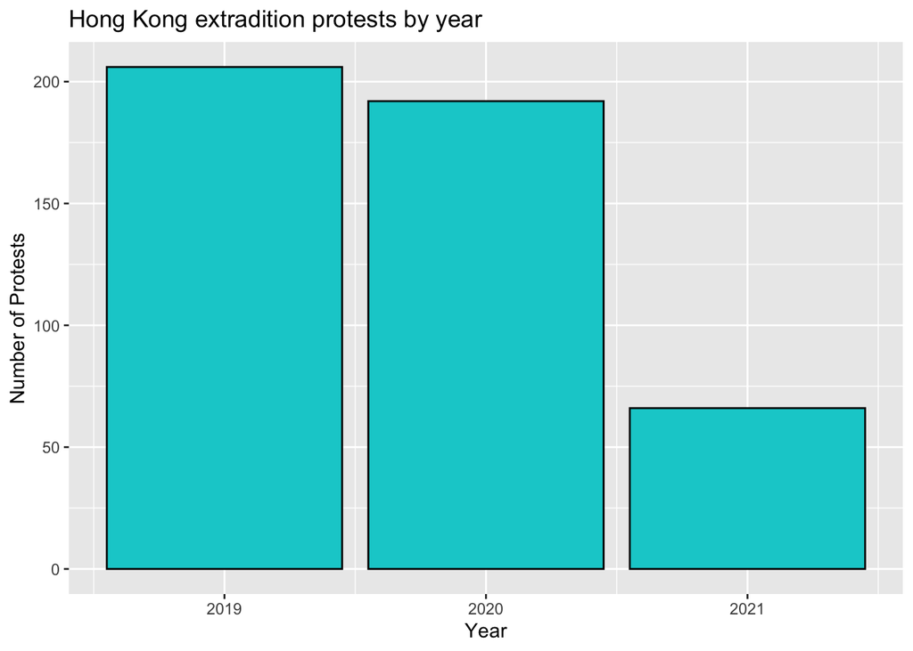

## Case Study: The Civil Human Rights Front

The Civil Human Rights Front, or CHRF, was one of the most prominent pro-democracy protest groups in Hong Kong. It organized the first major protest following the Extradition Bill, on March 31, 2019, with between 5,200 and 12,000 people in attendance, according to the ACLED data. And in June 2019, the group organized several marches that drew between a quarter of a million and two million people.

But CHRF [disbanded in August 2021](https://www.wsj.com/articles/group-behind-some-of-hong-kongs-biggest-protests-to-disband-11629017049) less than an year after the implementation of China’s National Security Law. Several of the group’s leaders had been arrested based on charges related to 2019 protests and the National Security Law, and the group as a whole was being investigated by the police, according to The Wall Street Journal, promoting the dissolution of the group. CHRF went from being involved in dozens of protests in 2019 to none in 2022.

It’s unclear why there were far fewer protests in 2020, but it’s likely because that was following the arrest of several CHRF leaders under the National Security Law as well as the [government’s rejection of CHRF’s applications](https://www.cnn.com/2021/08/15/asia/hong-kong-chrf-disbands-intl-hnk/index.html) to hold legal demonstrations in public spaces.

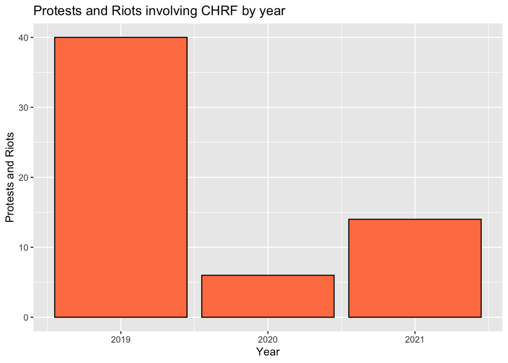

# Violence Against Civilians

There have been 33 acts of violence against civilians in Hong Kong since March 31, 2019. Many of the events have a clear tie to the pro-democracy movement or pro-China support, such as the July 23, 2020 attack on a pro-democracy cafe owner with a screwdriver, which led the victim to be hospitalized for his injuries.

For those that don’t explicitly state such a connection, it’s impossible to tell whether they were connected or not, as the information may have just been omitted.For example, on May 11, 2021, a reporter from the Epoch Times was attacked. The data does not say why; However, The Epoch Times is a far-right publication associated with a religious group that is banned in mainland China, so it’s possible that the attacker was motivated by pro-China ideology.

| Event Type | Date | Description |
| --- | --- | --- |
| Violence against civilians | 11 May 2021 | On 11 May 2021, a female reporter for Epoch Times - also head of the Hong Kong Association of Falun Dafa - was assaulted by an unidentified assailant near her Ho Man Tin residence in Kowloon City dist… |
| Violence against civilians | 29 August 2020 | On 29 August 2020, a group of around 10 black-clad men punched, kicked and attacked three white-clad and black-clad teenagers with glass bottles, axes and hiking poles at Chi Cheong Road, Sheung Shui,… |
| Violence against civilians | 17 August 2020 | On 17 August 2020, 10 immigration officers beat up one of the detainees at Castle Peak Bay Immigration Center, Tuen Mun district (Hong Kong), after the man refused a request on 16 Aug to visit the hos… |
| Violence against civilians | 23 July 2020 | On 23 July 2020, two men assaulted a pro-democracy cafe owner with a screwdriver at his own cafe on Sai Yu Street, Yuen Long District (Hong Kong). This was the second of two attacks on the owner and h… |
| Violence against civilians | 06 July 2020 | On 6 July 2020, an restaurant employee was assaulted by two unemployed men at the restaurant in Tsim Sha Tsui, Yau Tsim Mong district (Hong Kong) with glass bottles and hard objects. The restaurant wa… |
| Violence against civilians | 28 June 2020 | On 28 June 2020, a pro-democracy 'yellow shop' owner and his wife were assaulted by 4 unidentified assailants near their restaurant on Sai Yu Street, Yuen Long District (Hong Kong). It was reported th… |
| Violence against civilians | 28 June 2020 | On 28 June 2020, a woman and her 9-year-old son were attacked by two men near a street booth for pro-Beijing group 'Protect Hong Kong Alliance' on a footbridge connected to the Long Ping MTR station i… |
| Violence against civilians | 12 June 2020 | On 12 June 2020, a man (who was later identified to be a former community officer of DAB) attacked an Epoch Times reporter and members of the public with a knife at Kwun Tong Station (Yue Man Square) … |
| Violence against civilians | 10 June 2020 | On 10 June 2020, a middle-aged pro-establishment man attacked a female online media reporter at Citygate, Tung Chung in Islands District (Hong Kong). The reporter was at the scene filming two demonstr… |
| Violence against civilians | 24 May 2020 | On 24 May 2020, an unidentified man was reportedly harassing and insulting volunteers who were stationed at a street booth opposite Fortune Plaza in Tai Po District (Hong Kong), campaigning and collec… |

[output cut: 23 more lines]

## Declination in acts of violence

Acts of violence against civilians peaked in 2019 and have steadily declined each year since, with no such acts yet in 2022.

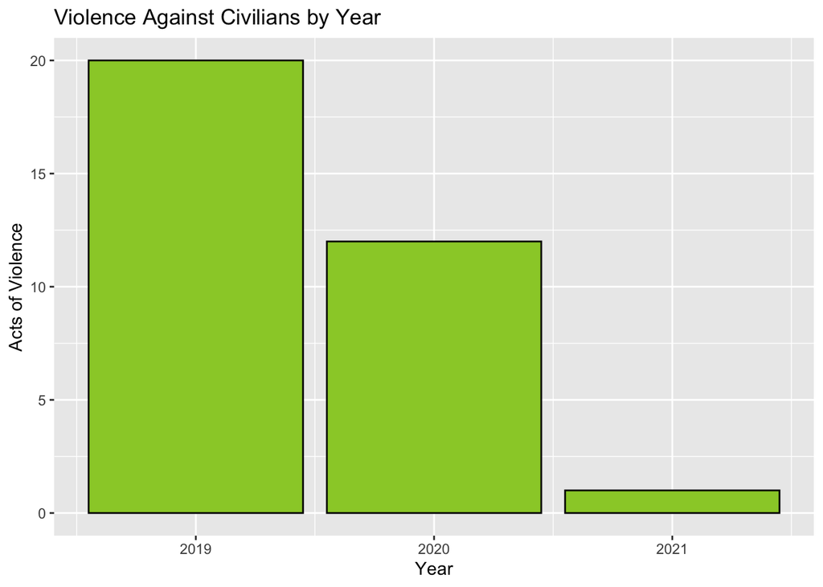

# Methodology

As a first step, I filtered the ACLED East Asia dataset to only include entries from China, which includes Hong Kong.

For the protest and riot data, I filtered that dataset for entries that were listed as event type “Protests” or “Riots.” Then, to make sure the data only included protests and riots related to the Extradition Bill, I filtered the data to include only events where the notes included the words “democracy,” “extradition,” “independence” or “pro-democracy.” This got rid of all unrelated protests and riots.

As for the violence against civilians data, because there were only 33 rows of data, instead of filtering for keywords, I just read each of the rows. Most of the 33 entry had explicit ties to the pro-democracy movement. Of the few that didn’t, they still had some type of political connection, making it impossible to know if they were tied to the movement or not. To be on the safe side, and because there were so few of this type of entry, I kept them in the data.

In order to study the CHRF protests, I created the searchable table of protests and riots, above, to search for the keyword “CHRF”. This enabled me to read the descriptions of each of the protests relavant to the group.

To make the bar chart of the CHRF protests, I used the same code as the bar chart for all of the protests and riots related to the Extradition Bill, but filtered for the keywords “CHRF” and “Civil Human Rights Front.”